# Pharmacodynamics and Exposure-Response Modelling

Population PK and PKPD | Worked examples in R

## Learning Objectives

By the end of this session, you should be able to:

1. Distinguish dose-response from concentration-response and exposure-response.
2. Interpret baseline, maximum effect, potency, and Hill slope.
3. Fit a simple nonlinear response model and a population model with `nlme`.
4. Explain why concentration and effect can peak at different times.
5. Distinguish sequential, intermediate, and joint PK/PD approaches.
6. Identify what a response dataset can and cannot establish.

## Session Plan

| Topic | Approximate time |
| --- | --- |
| Receptor theory and Emax models | 20 minutes |
| Real data: PBG dose-response | 25 minutes |
| Synthetic population concentration-response | 25 minutes |
| Direct, effect-compartment, and indirect response | 25 minutes |
| PK/PD estimation strategies and interpretation | 15 minutes |
| Discussion and exercises | 10 minutes |

## R Setup

```r
library(ggplot2)
library(dplyr)
library(tidyr)
library(nlme)
library(deSolve)
theme_set(theme_minimal(base_size = 14))

emax <- function(C, Emax, EC50, E0 = 0, hill = 1) {
  E0 + Emax * C^hill / (EC50^hill + C^hill)
}
```

This lecture adapts the Emax and PK/PD simulation examples from `pkpd-lecture-v3.qmd`. Packages are loaded once; no installation or network access is required during execution.

## From Dose to Response

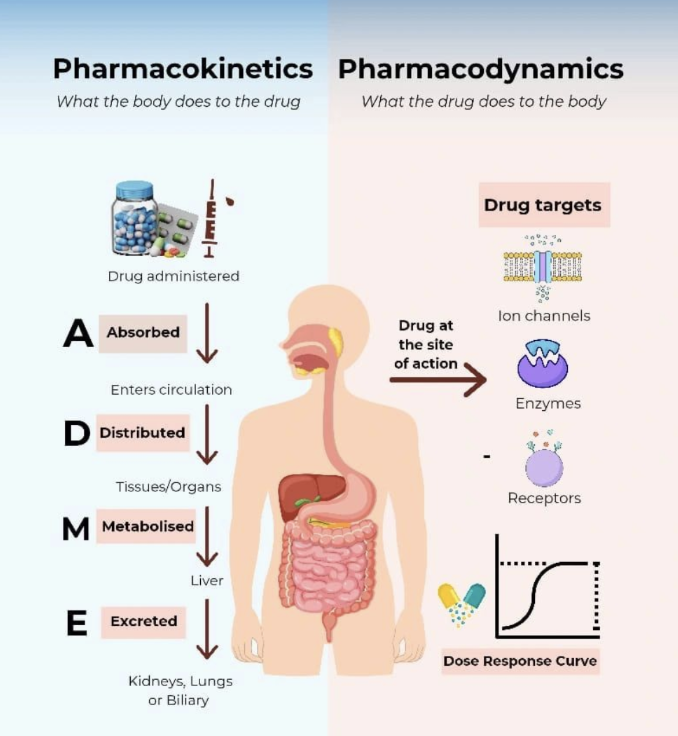

The PK/PD chain

**Dose -> concentration over time -> pharmacological response.**

PK describes drug disposition. PD describes the relationship between drug concentration and response, including delays and biological turnover.

## Dose, Concentration, and Exposure

| Predictor | Example | Half-maximal parameter |
| --- | --- | --- |
| Administered dose | Micrograms injected | ED50 |
| Concentration | Plasma concentration in mg/L | EC50 or IC50 |
| Summary exposure | AUC, peak, or trough concentration | Depends on the chosen metric |

A dose-response curve includes the consequences of both PK and PD. Two individuals can receive the same dose but have different concentrations and responses.

An AUC-response association is not automatically a mechanistic concentration-effect model. The exposure metric must match the biological question and endpoint timing.

## Receptor Occupancy: A Starting Point

For a simple equilibrium binding model:

$$f_{\mathrm{occupied}} = \frac{C_{\mathrm{free}}}{K_D + C_{\mathrm{free}}}.$$

At $C_{\mathrm{free}}=K_D$, half of the receptors are occupied.

If response is proportional to occupancy, this motivates a hyperbolic Emax relationship. Receptor reserve, signal amplification, active metabolites, and downstream regulation can break that proportionality: **EC50 need not equal $K_D$**.

## The Emax Model

$$E(C)=E_0+\frac{E_{\max}C^h}{EC_{50}^h+C^h}.$$

| Parameter | Interpretation |
| --- | --- |
| $E_0$ | Response without drug |
| $E_{\max}$ | Maximum change from baseline, in response units |
| $EC_{50}$ | Concentration giving half of that maximum change |
| $h$ | Empirical steepness parameter (Hill coefficient) |

The upper asymptote is $E_0+E_{\max}$. Emax need not be 100%, and a Hill coefficient above one does not by itself establish molecular cooperativity.

## Simulation: Potency

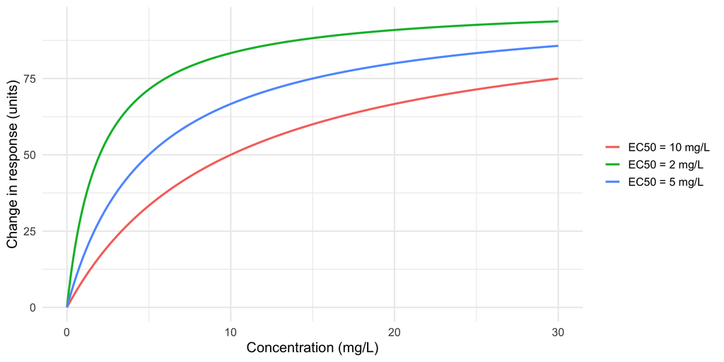

```r
potency <- expand.grid(C = seq(0, 30, 0.1), EC50 = c(2, 5, 10)) %>%
  mutate(effect = emax(C, 100, EC50),
         curve = paste("EC50 =", EC50, "mg/L"))
ggplot(potency, aes(C, effect, color = curve)) +
  geom_line(linewidth = 1) +
  labs(x = "Concentration (mg/L)", y = "Change in response (units)", color = NULL)
```

Lower EC50 means greater potency for this endpoint. All three curves share the same Emax.

## Simulation: Hill Slope

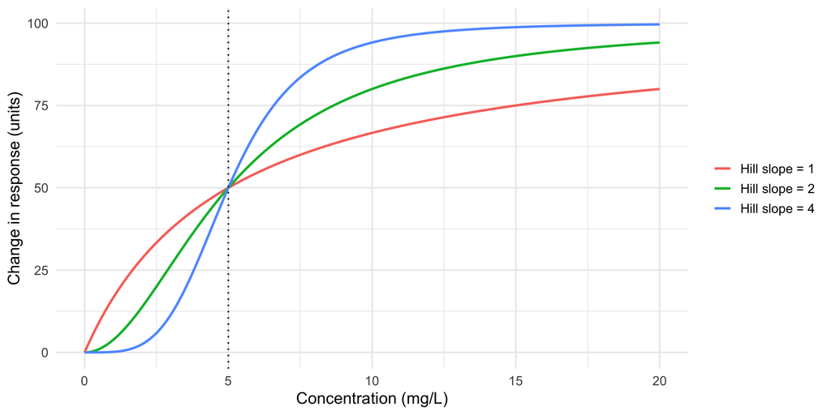

```r
hill_curves <- expand.grid(C = seq(0, 20, 0.05), hill = c(1, 2, 4)) %>%
  mutate(effect = emax(C, 100, 5, hill = hill),
         curve = paste("Hill slope =", hill))
ggplot(hill_curves, aes(C, effect, color = curve)) +
  geom_line(linewidth = 1) + geom_vline(xintercept = 5, linetype = "dotted") +
  labs(x = "Concentration (mg/L)", y = "Change in response (units)", color = NULL)
```

All curves pass through half-maximal effect at EC50. Higher Hill slopes concentrate the transition into a narrower concentration range.

## Inhibitory Responses

For a response suppressed by drug:

$$R(C)=R_0\left(1-\frac{I_{\max}C}{IC_{50}+C}\right),\qquad 0\le I_{\max}\le1.$$

IC50 gives half of the maximum inhibition, not necessarily a 50% reduction from baseline. If $I_{\max}=0.8$, the response at IC50 is $0.6R_0$.

## Real Data: Phenylbiguanide in Rabbits

`nlme::PBG` contains 60 observations from five rabbits. Each rabbit received ascending phenylbiguanide doses under placebo and MDL 72222 treatment.

```r
pbg <- as.data.frame(PBG)
pbg$Treatment <- relevel(pbg$Treatment, ref = "Placebo")
head(pbg)
```

```
  deltaBP   dose Run Treatment Rabbit
1     0.5   6.25  P1   Placebo      1
2     4.5  12.50  P1   Placebo      1
3    10.0  25.00  P1   Placebo      1
4    26.0  50.00  P1   Placebo      1
5    37.0 100.00  P1   Placebo      1
6    32.0 200.00  P1   Placebo      1
```

The response is change in blood pressure; the predictor is injected dose. **These are dose-response data, with no measured concentrations or response time course.**

Source: [nlme PBG documentation](https://stat.ethz.ch/CRAN/web/packages/nlme/refman/nlme.html#PBG) and [MASS Rabbit documentation](https://stat.ethz.ch/R-manual/R-devel/library/MASS/html/Rabbit.html).

## PBG: Observed Dose-Response

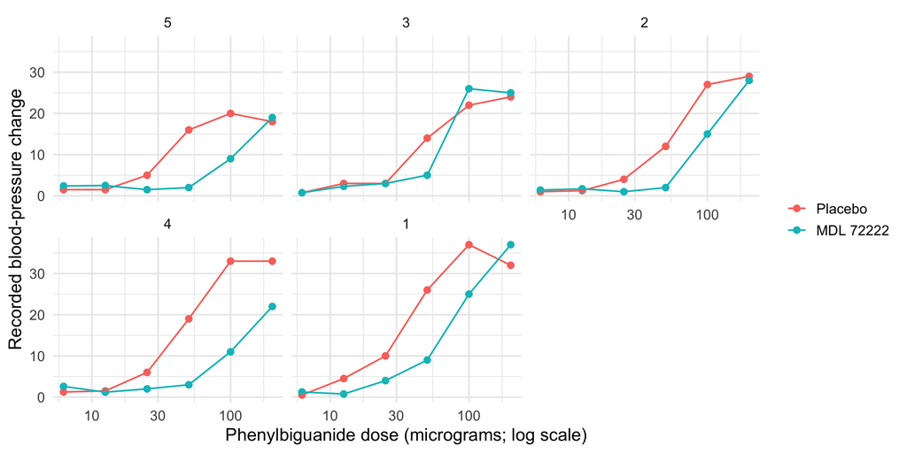

```r
ggplot(pbg, aes(dose, deltaBP, color = Treatment)) +
  geom_point(size = 2) + geom_line(aes(group = Treatment)) +
  scale_x_log10() + facet_wrap(~ Rabbit, nrow = 2) +
  labs(x = "Phenylbiguanide dose (micrograms; log scale)",
       y = "Recorded blood-pressure change", color = NULL)
```

Compare treatments within each rabbit. Does treatment change the apparent potency, the plateau, or both? Does either curve clearly reach a plateau?

## PBG: A Parsimonious Population Model

$$\Delta BP_{ij}=\frac{E_{\max,T}D_{ij}^2}{ED_{50,i,T}^2+D_{ij}^2}+\epsilon_{ij},$$
$$\log ED_{50,i,T}=\theta_{ED50,T}+\eta_i.$$

Treatment has fixed effects on log Emax and log ED50. A shared rabbit-level random effect on log ED50 respects the paired design.

For this introductory example, baseline is fixed at zero and Hill slope at two. These are modelling assumptions, not established biological facts. Five animals provide limited support for elaborate random-effects structures.

## PBG: Fit with nlme

```r
pbg_fit <- nlme(
  deltaBP ~ exp(logEmax) * dose^2 / (exp(logED50)^2 + dose^2),
  data = pbg,
  fixed = logEmax + logED50 ~ Treatment,
  random = logED50 ~ 1 | Rabbit,
  start = c(log(35), log(0.5), log(40), log(2))
)
fixef(pbg_fit)
```

```
       logEmax.(Intercept) logEmax.TreatmentMDL 72222
                 3.4578133                  0.2033952
       logED50.(Intercept) logED50.TreatmentMDL 72222
                 3.8840731                  0.9537605
```

```r
VarCorr(pbg_fit)
```

```
Rabbit = pdLogChol(list(logED50 ~ 1))
                    Variance   StdDev
logED50.(Intercept)  0.0776771 0.2787061
Residual            11.2190484 3.3494848
```

Log parameterization keeps Emax and ED50 positive. Starting values are intercepts and treatment contrasts on the log scale, in the order of the fixed-effects formulas.

## PBG: Population and Individual Predictions

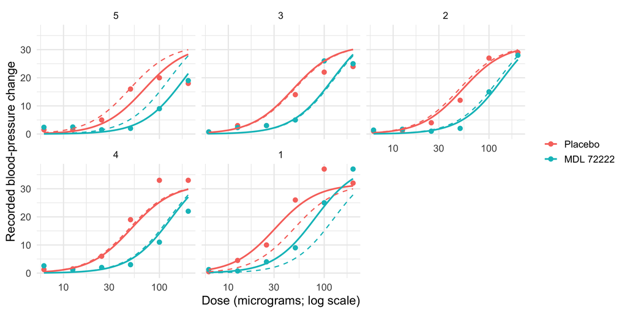

```r
pbg_grid <- expand.grid(
  dose = exp(seq(log(min(pbg$dose)), log(max(pbg$dose)), length.out = 100)),
  Rabbit = levels(pbg$Rabbit), Treatment = levels(pbg$Treatment)
)
pbg_grid$population <- predict(pbg_fit, pbg_grid, level = 0)
pbg_grid$individual <- predict(pbg_fit, pbg_grid, level = 1)
ggplot(pbg, aes(dose, deltaBP, color = Treatment)) +
  geom_point(size = 2) +
  geom_line(data = pbg_grid, aes(y = individual), linewidth = 0.9) +
  geom_line(data = pbg_grid, aes(y = population), linetype = "dashed") +
  scale_x_log10() + facet_wrap(~ Rabbit, nrow = 2) +
  labs(x = "Dose (micrograms; log scale)", y = "Recorded blood-pressure change",
       color = NULL)
```

Solid curves include estimated rabbit effects. Dashed curves set random effects to zero; they are typical-subject predictions, not necessarily the arithmetic population mean.

## PBG: Interpreting the Treatment Contrast

```r
b <- fixef(pbg_fit)
data.frame(
  Treatment = c("Placebo", "MDL 72222"),
  Emax = exp(c(b[1], b[1] + b[2])),
  ED50_micrograms = exp(c(b[3], b[3] + b[4]))
)
```

```
  Treatment     Emax ED50_micrograms
1   Placebo 31.74748        48.62185
2 MDL 72222 38.90834       126.19566
```

Under this model, treatment shifts the estimated dose-response relationship. When a plateau is poorly observed, Emax and ED50 can compensate for each other. Do not treat the fitted Emax contrast as proof of a change in receptor efficacy or infer a specific antagonism mechanism from these curves alone.

## PBG: Residual Checks

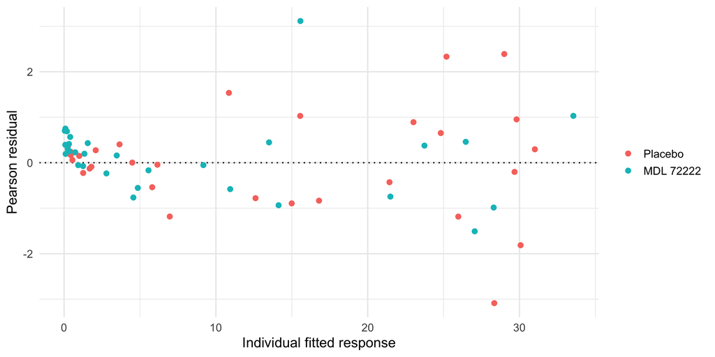

```r
pbg$residual <- residuals(pbg_fit, type = "pearson")
pbg$fitted <- fitted(pbg_fit)
ggplot(pbg, aes(fitted, residual, color = Treatment)) +
  geom_hline(yintercept = 0, linetype = "dotted") + geom_point(size = 2) +
  labs(x = "Individual fitted response", y = "Pearson residual", color = NULL)
```

Check for systematic patterns, unequal variability, and unusual rabbits. The model assumes conditionally independent additive errors; repeated ascending doses may require additional checks for order or carryover effects.

## Synthetic Data: Known Concentration-Response

To study EC50, we need concentrations. Generate an explicitly synthetic endpoint for 30 subjects at concentrations spanning below and above EC50.

```r
set.seed(42)
subjects <- data.frame(Subject = factor(seq_len(30)),
                       EC50 = 5 * exp(rnorm(30, sd = 0.3)))
pd_data <- expand.grid(Subject = subjects$Subject,
                      conc = c(0, 0.25, 0.5, 1, 2, 5, 10, 20, 40)) %>%
  left_join(subjects, by = "Subject") %>%
  mutate(effect = emax(conc, 100, EC50) + rnorm(n(), sd = 4))
head(pd_data)
```

```
  Subject conc     EC50    effect
1       1    0 7.543796  1.821800
2       2    0 4.220816  2.819349
3       3    0 5.575469  4.140414
4       4    0 6.045394 -2.435706
5       5    0 5.644708  2.019820
6       6    0 4.843321 -6.868035
```

True population Emax is 100 units, typical EC50 is 5 mg/L, and log EC50 random-effect SD is 0.3. Noise is additive with SD 4 units. Responses are continuous change scores; negative noisy values are retained rather than clipped.

## First Fit: Ignore the Grouping

```r
pooled_fit <- nls(
  effect ~ exp(logEmax) * conc / (exp(logEC50) + conc),
  data = pd_data, start = list(logEmax = log(80), logEC50 = log(8))
)
exp(coef(pooled_fit))
```

```
  logEmax   logEC50
99.376988  5.080349
```

This reuses the single-curve Emax fitting approach from the PK/PD lecture. It treats all observations as independent and gives no explicit estimate of between-subject variation.

## Population Emax Fit with nlme

```r
pd_fit <- nlme(
  effect ~ exp(logEmax) * conc / (exp(logEC50) + conc),
  data = pd_data,
  fixed = logEmax + logEC50 ~ 1,
  random = logEC50 ~ 1 | Subject,
  start = coef(pooled_fit)
)
data.frame(Parameter = c("Emax", "Typical EC50"),
           True = c(100, 5), Estimated = exp(fixef(pd_fit)))
```

```
           Parameter True  Estimated
logEmax         Emax  100 100.739010
logEC50 Typical EC50    5   5.252048
```

```r
VarCorr(pd_fit)
```

```
Subject = pdLogChol(list(logEC50 ~ 1))
         Variance   StdDev
logEC50   0.1398994 0.3740312
Residual 15.1512062 3.8924550
```

Compare estimated variability with the generating SD of 0.3. Individual EC50 estimates borrow information across subjects; they are not independent per-subject fits.

## Population and Individual Concentration-Response

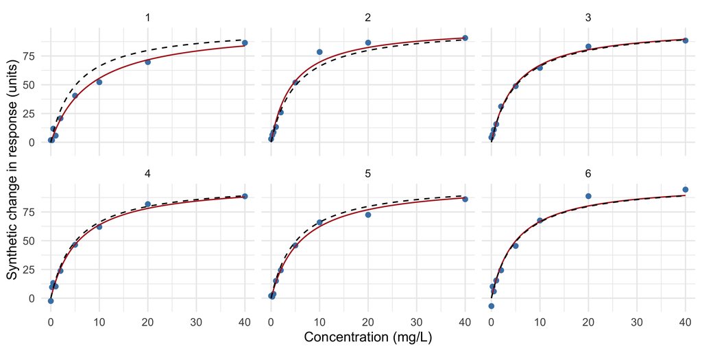

```r
pd_grid <- expand.grid(Subject = levels(pd_data$Subject)[1:6],
                       conc = seq(0, 40, length.out = 150))
pd_grid$individual <- predict(pd_fit, pd_grid, level = 1)
pd_grid$population <- predict(pd_fit, pd_grid, level = 0)
ggplot(filter(pd_data, Subject %in% pd_grid$Subject), aes(conc, effect)) +
  geom_point(color = "steelblue", size = 2) +
  geom_line(data = pd_grid, aes(y = individual), color = "firebrick") +
  geom_line(data = pd_grid, aes(y = population), linetype = "dashed") +
  facet_wrap(~ Subject, nrow = 2) +
  labs(x = "Concentration (mg/L)", y = "Synthetic change in response (units)")
```

Solid curves include subject effects; dashed curves represent a typical subject. These data are simulated, not measured PD outcomes from theophylline patients.

## Identifiability Depends on the Concentration Range

If every concentration is far below EC50:

$$E(C)-E_0\approx\frac{E_{\max}}{EC_{50}}C.$$

The data mainly identify the ratio Emax/EC50. Many pairs of parameters can produce similar curves.

Sample baseline, the transition region, and the plateau when feasible. A good-looking fit within the observed range may still extrapolate poorly. More subjects do not necessarily compensate for an uninformative concentration range.

## A Short PK Refresher

Reuse the one-compartment oral model with first-order absorption:

$$C(t)=\frac{FDk_a}{V(k_a-k_e)}\left(e^{-k_et}-e^{-k_at}\right),\qquad k_e=CL/V.$$

```r
pk_oral <- function(time, dose, ka = 1.2, CL = 4, V = 20) {
  ke <- CL / V
  dose * ka / (V * (ka - ke)) * (exp(-ke * time) - exp(-ka * time))
}
```

In the simulations below, dose is in mg, V in L, CL in L/h, and bioavailability is fixed at one. Parameters are illustrative, not patient estimates.

## Direct Response: Concentration and Effect over Time

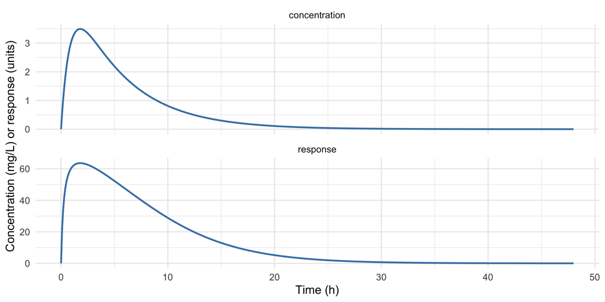

```r
direct <- data.frame(time = seq(0, 48, by = 0.1)) %>%
  mutate(concentration = pk_oral(time, dose = 100),
         response = emax(concentration, 100, 2))
direct %>% pivot_longer(c(concentration, response), names_to = "Endpoint") %>%
  ggplot(aes(time, value)) + geom_line(color = "steelblue", linewidth = 1) +
  facet_wrap(~ Endpoint, ncol = 1, scales = "free_y") +
  labs(x = "Time (h)", y = "Concentration (mg/L) or response (units)")
```

A direct Emax relationship changes the shape and scale, but introduces no temporal delay: the same concentration produces the same response on the rising and falling limbs.

## Effect Compartment: A Distributional Delay

$$\frac{dC_e}{dt}=k_{e0}(C_p-C_e),\qquad E(t)=\frac{E_{\max}C_e}{EC_{50}+C_e}.$$

The hypothetical effect compartment links plasma concentration to an effect-site concentration. It does not remove a material amount of drug from the PK system.

The equilibration half-life is $\log(2)/k_{e0}$. Slow equilibration can delay the effect peak and produce hysteresis when effect is plotted against plasma concentration.

## Simulating an Effect Compartment

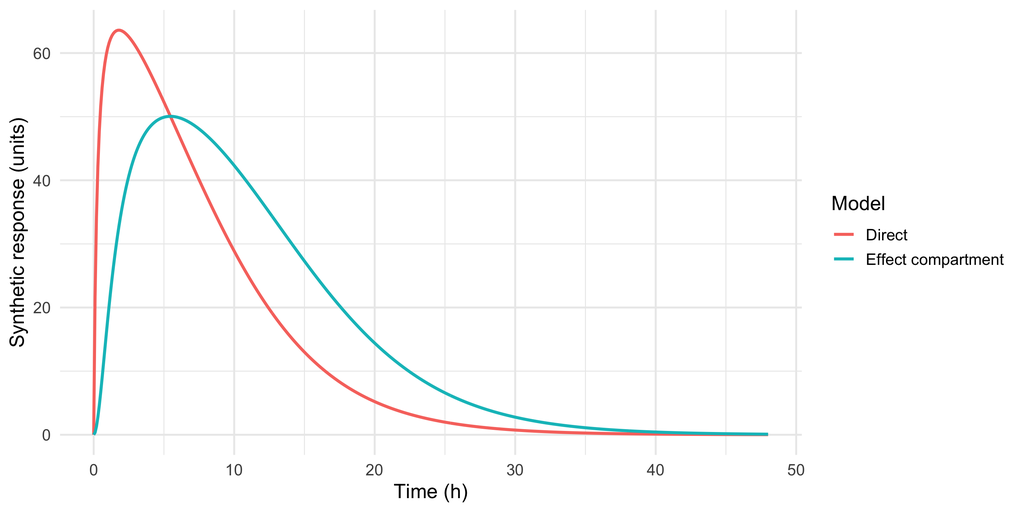

```r
effect_rhs <- function(time, state, pars) {
  cp <- pk_oral(time, dose = pars[["dose"]])
  list(c(Ce = pars[["ke0"]] * (cp - state[["Ce"]])))
}
delayed <- as.data.frame(ode(
  y = c(Ce = 0), times = direct$time, func = effect_rhs,
  parms = c(dose = 100, ke0 = 0.25)
)) %>% mutate(concentration = pk_oral(time, 100),
              response = emax(Ce, 100, 2))
bind_rows(transmute(direct, time, response, Model = "Direct"),
          transmute(delayed, time, response, Model = "Effect compartment")) %>%
  ggplot(aes(time, response, color = Model)) + geom_line(linewidth = 1) +
  labs(x = "Time (h)", y = "Synthetic response (units)")
```

## Hysteresis: The Same Plasma Concentration, Different Effects

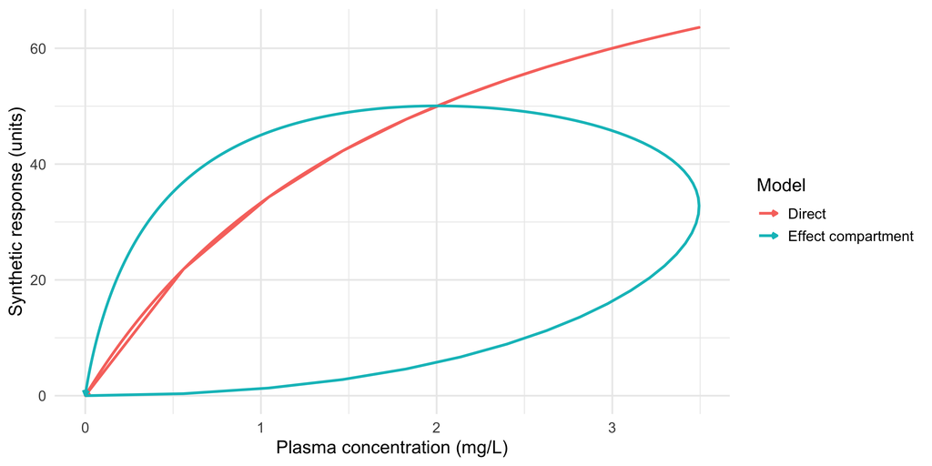

```r
bind_rows(transmute(direct, time, concentration, response, Model = "Direct"),
          transmute(delayed, time, concentration, response,
                    Model = "Effect compartment")) %>%
  ggplot(aes(concentration, response, color = Model)) +
  geom_path(linewidth = 1, arrow = grid::arrow(length = grid::unit(0.15, "cm"))) +
  labs(x = "Plasma concentration (mg/L)", y = "Synthetic response (units)")
```

Paths follow time order. A loop flags a failure of the instantaneous plasma concentration-response assumption; it does not uniquely identify the mechanism of delay.

## Indirect Response: Biological Turnover

At baseline, response production and loss balance:

$$\frac{dR}{dt}=k_{in}-k_{out}R,\qquad R_0=\frac{k_{in}}{k_{out}}.$$

For drug inhibition of production:

$$\frac{dR}{dt}=k_{in}\left(1-\frac{I_{\max}C_p}{IC_{50}+C_p}\right)-k_{out}R.$$

Drug changes a process controlling the biomarker. Response falls and recovers according to turnover, even if the concentration-effect interaction itself is instantaneous.

## Four Basic Indirect-Response Mechanisms

| Drug action | Modified equation |
| --- | --- |
| Inhibit production | $k_{in}(1-I(C))-k_{out}R$ |
| Stimulate production | $k_{in}(1+S(C))-k_{out}R$ |
| Inhibit loss | $k_{in}-k_{out}(1-I(C))R$ |
| Stimulate loss | $k_{in}-k_{out}(1+S(C))R$ |

Here $I(C)=I_{\max}C/(IC_{50}+C)$ and $S(C)=S_{\max}C/(SC_{50}+C)$. Choose the mechanism using endpoint biology and the observed time course, not merely the best fit.

## Simulating Turnover and Recovery

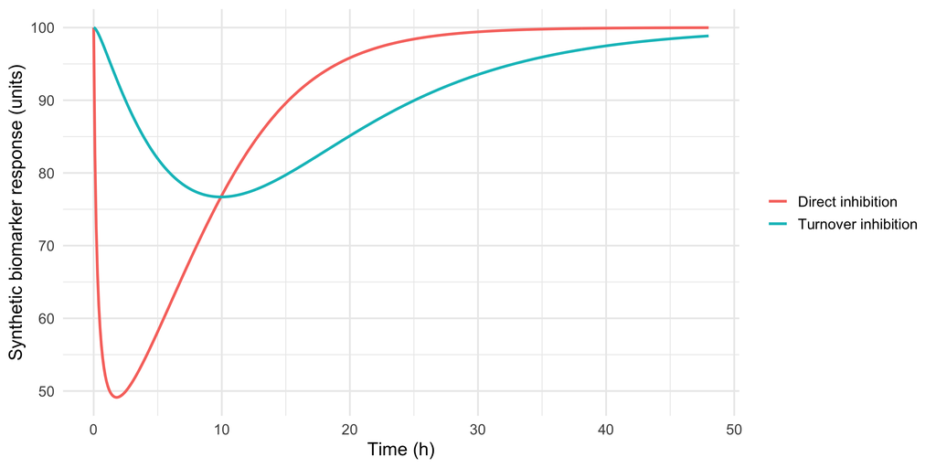

```r
turnover_rhs <- function(time, state, pars) {
  cp <- pk_oral(time, pars[["dose"]])
  inhibition <- pars[["Imax"]] * cp / (pars[["IC50"]] + cp)
  list(c(R = pars[["kin"]] * (1 - inhibition) - pars[["kout"]] * state[["R"]]))
}
turnover <- as.data.frame(ode(
  y = c(R = 100), times = direct$time, func = turnover_rhs,
  parms = c(dose = 100, kin = 10, kout = 0.1, Imax = 0.8, IC50 = 2)
)) %>% mutate(direct_response = 100 * (1 - 0.8 *
                                        pk_oral(time, 100) / (2 + pk_oral(time, 100))))
turnover %>% pivot_longer(c(R, direct_response), names_to = "Model") %>%
  ggplot(aes(time, value, color = Model)) + geom_line(linewidth = 1) +
  scale_color_discrete(labels = c("Direct inhibition", "Turnover inhibition")) +
  labs(x = "Time (h)", y = "Synthetic biomarker response (units)", color = NULL)
```

Baseline is 100 because kin/kout = 10/0.1. The turnover model delays the response nadir and recovery.

## Dosing Interval: Similar Exposure, Different Response Profiles

Reuse superposition from the PK lecture to simulate repeated oral doses. Compare 100 mg every 24 h with 50 mg every 12 h: both supply 100 mg per day.

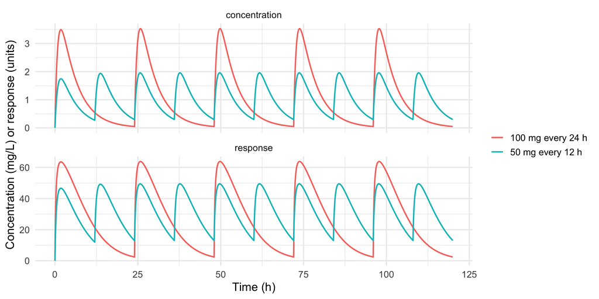

```r
repeated_cp <- function(time, dose, interval) {
  dose_times <- seq(0, max(time), by = interval)
  vapply(time, function(t) {
    sum(pk_oral(t - dose_times[dose_times <= t], dose))
  }, numeric(1))
}
regimens <- expand.grid(time = seq(0, 120, 0.1),
                        Regimen = c("100 mg every 24 h", "50 mg every 12 h")) %>%
  group_by(Regimen) %>%
  mutate(concentration = repeated_cp(time,
             if (first(Regimen) == "100 mg every 24 h") 100 else 50,
             if (first(Regimen) == "100 mg every 24 h") 24 else 12),
         response = emax(concentration, 100, 2)) %>% ungroup()
regimens %>% pivot_longer(c(concentration, response), names_to = "Endpoint") %>%
  ggplot(aes(time, value, color = Regimen)) + geom_line(linewidth = 0.8) +
  facet_wrap(~ Endpoint, ncol = 1, scales = "free_y") +
  labs(x = "Time (h)", y = "Concentration (mg/L) or response (units)", color = NULL)
```

Under linear PK, equal daily dose gives equal steady-state AUC per day. Peak, trough, and nonlinear response profiles can still differ. These are illustrative simulations, not dosing recommendations.

## Sequential, Intermediate, and Joint PK/PD

| Approach | What is estimated | Main tradeoff |
| --- | --- | --- |
| Sequential | Fit PK, then condition PD on fixed PK estimates or predictions | Simpler; naive plug-in fitting does not propagate PK uncertainty |
| Intermediate | Fix selected population PK components while estimating other quantities with PD | Compromise; specify exactly what is fixed and estimated |
| Joint | Estimate PK and PD together using both endpoints | Shares information; greater computational and identifiability demands |

Terminology for intermediate approaches varies. Distinguish fixing population PK parameters, fixing individual PK estimates, and using observed concentrations directly.

## What We Have Actually Estimated

The PBG fit estimates a **dose-response population model**.

The synthetic Emax fit estimates a **concentration-response population model**, assuming the predictor concentrations are known without error.

The ODE examples **simulate** linked PK/PD systems. They do not fit a joint model. Using `nlme` for nonlinear response curves is not equivalent to a general-purpose joint PK/PD estimation workflow.

## Exposure-Response Interpretation

- Check whether the chosen exposure metric captures the relevant timing.
- Distinguish prediction within the observed range from extrapolation.
- Consider baseline disease, adherence, dose modifications, and other confounders.
- Separate uncertainty in typical parameters, between-subject variation, and residual noise.
- Assess benefit and adverse effects together when discussing dose selection.

An exposure-response association alone does not establish causality or a clinical dose.

## Exercises

1. Change Emax while keeping EC50 fixed. How do potency and maximum response differ?
2. Refit PBG with Hill slope fixed at one. Compare residuals, fitted curves, and AIC; explain what changes.
3. Restrict synthetic data to concentrations below 2 mg/L. What happens to Emax and EC50 estimates?
4. Halve ke0. Predict the change in delay before running the effect-compartment simulation.
5. Halve kout and kin together. Explain why baseline stays constant but turnover slows.
6. Explain why neither PBG nor a good Emax curve alone establishes a clinical dosing regimen.

## Take-Home Points

Dose-response, concentration-response, and summary exposure-response answer related but different questions.

Emax separates maximum response from potency; parameter interpretation depends on endpoint and model assumptions.

Population models distinguish systematic treatment effects from individual variation. Real data and known-truth simulations are complementary teaching tools.

Delayed response requires a time-course model. Effect-site equilibration and biological turnover can both cause delay but represent different mechanisms.

## References and Further Reading

- Pinheiro JC, Bates DM. *Mixed-Effects Models in S and S-PLUS*. Springer, 2000. [nlme documentation](https://stat.ethz.ch/CRAN/web/packages/nlme/refman/nlme.html).
- Ludbrook J. Repeated measurements and multiple comparisons in cardiovascular research. *Cardiovascular Research*. 1994;28:303-311. PBG data provenance: [MASS Rabbit](https://stat.ethz.ch/R-manual/R-devel/library/MASS/html/Rabbit.html).
- [nlme nonlinear model reference](https://stat.ethz.ch/R-manual/R-patched/library/nlme/html/nlme.html).
- [Exposure-response and turnover simulation examples](https://nlmixr2.github.io/rxode2/articles/rxode2-exposure-response.html). Further reading only; this lecture uses `deSolve`, not `nlmixr2` or `rxode2`.
- Local source material: `pkpd-lecture-v3.qmd`, Emax fitting, direct PK/PD relationships, oral PK, repeated dosing, and numerical ODE workflows.